# Reproducible Research: Peer Assessment 1

## Pre-Requisites

The following packages are required:

- data.tables
- xtable
- lattice

the following R version was used to perform these calculations:

```r
xt <- version
#output results which include mean and median
print(xt, type='html')
```

[output not shown]

platform x86_64-w64-mingw32  
arch x86_64  
os mingw32  
system x86_64, mingw32  
status  
major 3  
minor 1.0  
year 2014  
month 04  
day 10  
svn rev 65387  
language R  
version.string R version 3.1.0 (2014-04-10) nickname Spring Dance

## Loading and preprocessing the data

### Sources

The data for this assignment can be downloaded from the course web site:

- Dataset: [Activity monitoring data](https://d396qusza40orc.cloudfront.net/repdata%2Fdata%2Factivity.zip) [52K]

The variables included in this dataset are:

- **steps**: Number of steps taking in a 5-minute interval (missing values are coded as `NA`)
- **date**: The date on which the measurement was taken in YYYY-MM-DD format
- **interval**: Identifier for the 5-minute interval in which measurement was taken

The dataset is stored in a comma-separated-value (CSV) file and there are a total of 17,568 observations in this dataset.

### Preparation

Steps to download and prepare the file are as follows:

1. Create a temp. file name (eg tempfile())
2. Use download.file() to fetch the file into the temp. file
3. Use unz() to extract the target file from temp. file
4. Remove the temp file via unlink()

no further preparation is immediately performed, since the some output requires analysis of `NA` values.

The data used to prepare this document was downloaded on Mon Jul 14 10:40:56 2014

```r
  temp <- tempfile()
  download.file("http://d396qusza40orc.cloudfront.net/repdata%2Fdata%2Factivity.zip",temp)
  data <- read.csv(unz(temp, "activity.csv"), header=T)
  unlink(temp)
```

## What is mean total number of steps taken per day?

For this part of the assignment,missing values in the dataset can be ignored. histogram will igore `NA` values so no need to remove them, outputs are the same.

### Make a histogram of the total number of steps taken each day

First step here is to aggregate total steps for each day in the data set. We will use the a data table to speed up this process. In this case, we remove `NA` values from the sum.

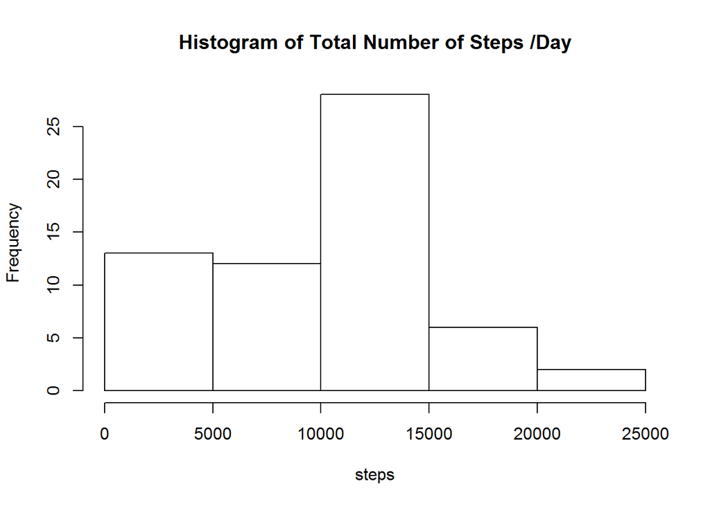

```r
library(data.table)
dt<-data.table(data)
dt.agg <- dt[, sum(steps, na.rm=T), by=date]
hist(dt.agg$V1 , main="Histogram of Total Number of Steps /Day", xlab="steps")
```

2. Calculate and report the **mean** and **median** total number of steps taken per day

```r
library(xtable)
# Transpose summary table to a format xtable can use
dt.sum <- summary(dt.agg$V1)
dt.t <- t(t(dt.sum))
xt <- xtable(dt.t)
#output results which include mean and median
print(xt, type='html')
```

|  | x |
| --- | --- |
| Min. | 0.00 |
| 1st Qu. | 6780.00 |
| Median | 10400.00 |
| Mean | 9350.00 |
| 3rd Qu. | 12800.00 |
| Max. | 21200.00 |

## What is the average daily activity pattern?

### Make a time series plot (i.e. `type = "l"`) of the 5-minute interval (x-axis) and the average number of steps taken, averaged across all days (y-axis)

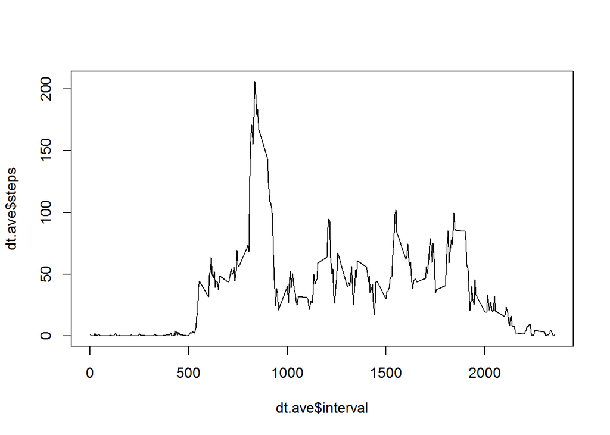

```r
#get rid of NA values for mean calcs
d<-na.omit(dt)
dt.ave <- d[, mean(steps, na.rm=T), by=interval]
setnames(dt.ave,c('interval','steps'))
plot(dt.ave$interval,dt.ave$steps, type="l")
```

### Which 5-minute interval, on average across all the days in the dataset, contains the maximum number of steps?

```r
maxInterval <- dt.ave[dt.ave$steps==max(dt.ave$steps)]
xt <- xtable(maxInterval)
#output results which include mean and median
print(xt, type='html')
```

|  | interval | steps |
| --- | --- | --- |
| 1 | 835 | 206.17 |

Which indicates, the maximum interval is **835** with an average of **206.1698** steps

## Imputing missing values

### Calculate and report the total number of missing values in the dataset (i.e. the total number of rows with `NA`s)

using the summary command, we see there are **2304** `NA` values.

```r
summary(data)
```

```
##      steps               date          interval
##  Min.   :  0.0   2012-10-01:  288   Min.   :   0
##  1st Qu.:  0.0   2012-10-02:  288   1st Qu.: 589
##  Median :  0.0   2012-10-03:  288   Median :1178
##  Mean   : 37.4   2012-10-04:  288   Mean   :1178
##  3rd Qu.: 12.0   2012-10-05:  288   3rd Qu.:1766
##  Max.   :806.0   2012-10-06:  288   Max.   :2355
##  NA's   :2304    (Other)   :15840
```

### Devise a strategy for filling in all of the missing values in the dataset.

Conventional Imputation typically uses multiple methods to substitutes estimated values for missing values

- Replacement with means
- Regression imputation (replace with conditional means)

The problem is that these methods

- Often leads to biased parameter estimates (e.g., variances)
- Usually leads to standard error estimates that arebiased downward
- Treats imputed data as real data, ignores inherent uncertainty in imputed values.

However, given that in this case the strategy does not need to be sophisticated. I have elected to replace all `NA` values with the mean value for that 5-minute interval. The dataset follows.

### Create a new dataset that is equal to the original dataset but with the missing data filled in.

The new dataset called `dt.impute` is created as follows:

```r
dt.noNA <- data[!is.na(data$steps),]
dt.na <- data[is.na(data$steps),]
dt.m <- merge(x=dt.na, y=dt.ave, by='interval')
dt.impute <- rbind(dt.noNA, data.table(interval=dt.m$interval, steps=dt.m$steps.y, date=dt.m$date), use.names=T)
summary(dt.impute)
```

```
##      steps               date          interval
##  Min.   :  0.0   2012-10-01:  288   Min.   :   0
##  1st Qu.:  0.0   2012-10-02:  288   1st Qu.: 589
##  Median :  0.0   2012-10-03:  288   Median :1178
##  Mean   : 37.4   2012-10-04:  288   Mean   :1178
##  3rd Qu.: 27.0   2012-10-05:  288   3rd Qu.:1766
##  Max.   :806.0   2012-10-06:  288   Max.   :2355
##                  (Other)   :15840
```

### Make a histogram of the total number of steps taken each day and Calculate and report the mean and median total number of steps taken per day.

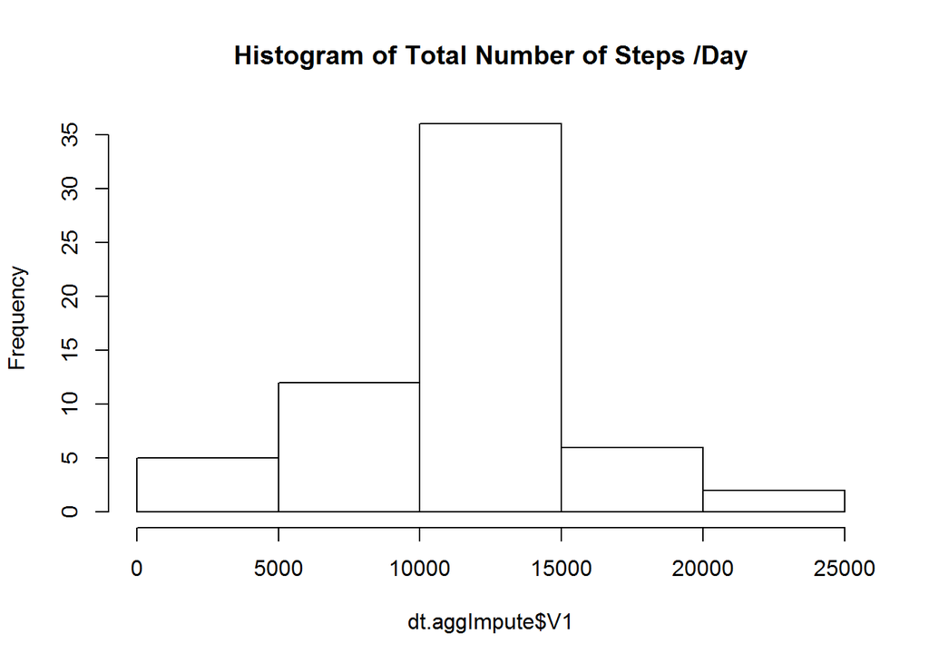

```r
dt.aggImpute <- dt.impute[, sum(steps, na.rm=T), by=date]
hist(dt.aggImpute$V1 , main="Histogram of Total Number of Steps /Day")
```

```r
dt.sum <- summary(dt.aggImpute$V1)
dt.t2 <- t(t(dt.sum))
xt <- xtable(dt.t2)
#output results which include mean and median
print(xt, type='html')
```

|  | x |
| --- | --- |
| Min. | 41.00 |
| 1st Qu. | 9820.00 |
| Median | 10800.00 |
| Mean | 10800.00 |
| 3rd Qu. | 12800.00 |
| Max. | 21200.00 |